# Fledglings

Author

Mara Bodenmann

Published

April 24, 2026

Research question:

How do environmental stressors and resource availability influence reproductive success?

## 1 Prepare Session

Import libraries

```r
  library(pastecs)
  library(ggpubr); theme_set(theme_bw())
  library(GGally)
  library(performance)
  library(MuMIn)
  library(ggeffects)
  library(tidyverse)

  library(knitr)
```

Import the data

```r
clean <- read_csv("data/processed/clean.CSV")
```

Modify the data

```r
#deal with NA--> remove the row with this NA
fledglings<- clean%>%
  select(n_fledglings, insect_abundance, env_noise)%>%
  na.omit() #removes rows with na, can specify column: filter(!is.na(column_name))
```

Here the flags and the row with the NA was removed.

## 2 Explore the data

### 2.1 Numerically

```r
numexp<-stat.desc(fledglings,norm = T)

kable(numexp, digits=1)
```

Table 1: Numerical exploration of the data

|  | n_fledglings | insect_abundance | env_noise |
| --- | --- | --- | --- |
| nbr.val | 39.0 | 39.0 | 39.0 |
| nbr.null | 0.0 | 0.0 | 0.0 |
| nbr.na | 0.0 | 0.0 | 0.0 |
| min | 3.0 | 6.0 | 45.0 |
| max | 7.0 | 16.0 | 68.0 |
| range | 4.0 | 10.0 | 23.0 |
| sum | 186.0 | 415.0 | 2250.0 |
| median | 5.0 | 11.0 | 58.0 |
| mean | 4.8 | 10.6 | 57.7 |
| SE.mean | 0.2 | 0.5 | 1.0 |
| CI.mean.0.95 | 0.4 | 1.0 | 2.1 |
| var | 1.8 | 9.1 | 41.1 |
| std.dev | 1.3 | 3.0 | 6.4 |
| coef.var | 0.3 | 0.3 | 0.1 |
| skewness | 0.2 | 0.1 | -0.2 |
| skew.2SE | 0.3 | 0.1 | -0.3 |
| kurtosis | -1.2 | -1.2 | -1.1 |
| kurt.2SE | -0.8 | -0.8 | -0.7 |
| normtest.W | 0.9 | 1.0 | 1.0 |
| normtest.p | 0.0 | 0.1 | 0.2 |

### 2.2 Graphically

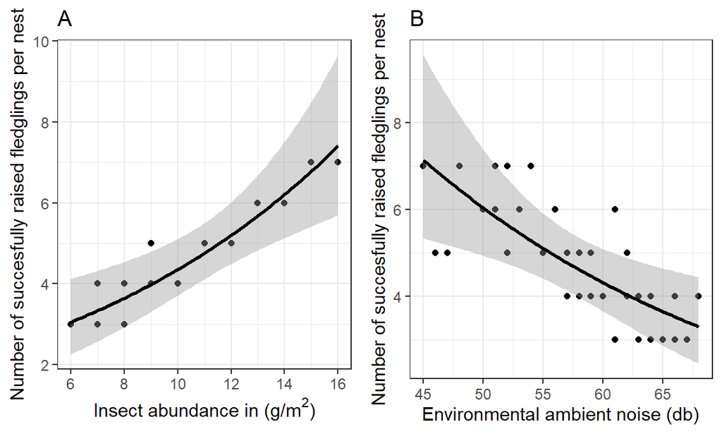

Figure 1: Raw data to visualize the relationship between successfully raised fledglings per nest, A: Insect abundance close to the nest and B: the environmental ambient noise.

```r
expgraph<-ggarrange(
  ggplot(fledglings, aes(x=insect_abundance,y=n_fledglings))+
    geom_point()+
    geom_smooth(method= glm, method.args= list(family= "poisson"),
                  col= "black")+
    labs(x=expression("Insect abundance in (g/m" ^2*")"), y="Number of succesfully raised fledglings per nest", title="A"),
  ggplot(fledglings, aes(x=env_noise,y=n_fledglings))+
    geom_point()+
    geom_smooth(method= glm, method.args= list(family= "poisson"),
                  col= "black")+
    labs(x="Environmental ambient noise (db)", y="Number of succesfully raised fledglings per nest", title="B")
)
expgraph
```

## 3 Fit the models

Fitting different models to see which one is most suitable for the data

```r
mod1<-glm(n_fledglings~ 1, family= "poisson", data=fledglings)
mod2<-glm(n_fledglings~ insect_abundance + env_noise , family= "poisson", data=fledglings)
mod3<-glm(n_fledglings~ insect_abundance * env_noise , family= "poisson", data=fledglings)
```

### 3.1 Evaluate the models

Choose which one fits the best.

```r
anv.models<-anova(mod1,mod2,mod3)
kable(anv.models)
```

Table 2: A table showing he evaluation of the models 1-3

| Resid. Df | Resid. Dev | Df | Deviance | Pr(>Chi) |
| --- | --- | --- | --- | --- |
| 38 | 14.0750265 | NA | NA | NA |
| 36 | 1.0081370 | 2 | 13.0668895 | 0.0014540 |
| 35 | 0.9894048 | 1 | 0.0187322 | 0.8911371 |

The model I choose is model 2 where there is no interaction between the insect abundance and the environment noise. Because with the interaction, the model was not significantly better than the one without the interaction.

## 4 Validate the model

Validate whether I should proceed with the model

First I have to check for overdispersion because it is a glm!

```r
check_overdispersion(mod2)
```

```
# Overdispersion test

       dispersion ratio = 0.028
  Pearson's Chi-Squared = 1.020
                p-value =     1
```

There was no overdispersion detected, we can continue with checking the model.

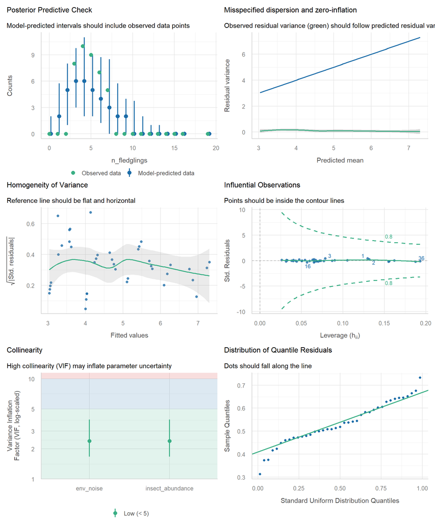

Figure 2: Model diagnostic

```r
check_model(mod2)
```

## 5 Interpreting the model

```r
#coefficients
coef.table<-round(summary(mod2)$coefficients,3)

#chi^2 of my model
null.chi<-anova(mod1,mod2)

#get r squared adjusted
r.2<- round(attributes(r.squaredLR(mod2))$adj.r.squared, 3)

#prepare the predictions plot
pred.mod<-predict_response(mod2)

#make the plot
pred.plot <-ggarrange(
  ggplot(pred.mod$insect_abundance, aes(x,predicted))+
    geom_point(data=fledglings,aes(x=insect_abundance,y=n_fledglings))+
    geom_ribbon(aes(ymin= conf.low, ymax= conf.high), alpha=0.2)+
    geom_line()+
    labs(x=expression("Insect abundance in (g/m" ^2*")"), y="Number of succesfully raised fledglings per nest", title = "A"),
  ggplot(pred.mod$env_noise, aes(x,predicted))+
    geom_point(data=fledglings,aes(x=env_noise,y=n_fledglings))+
    geom_ribbon(aes(ymin= conf.low, ymax= conf.high), alpha=0.2)+
    geom_line()+
    labs(x="Envronmental ambient noise (db)", y="Number of succesfully raised fledglings per nest", title = "B"),
  ncol=2,nrow=1

)
```

[output not shown]

Table 3: Standard errors and statistical significance of the parameters estimated by a poisson GLM. ($R^2$= 0.291 , $\chi^2_{( 2 , 36 )}$= 13.067 , $p$ 0.001454 )

|  | Estimate | Std. Error | z value | Pr(>\|z\|) |
| --- | --- | --- | --- | --- |
| (Intercept) | 0.933 | 1.386 | 0.673 | 0.501 |
| insect_abundance | 0.081 | 0.038 | 2.115 | 0.034 |
| env_noise | -0.005 | 0.018 | -0.259 | 0.796 |

A poisson Generalized Linear Model (*R*<sup>2</sup>= 0.291 , $\chi^2_{( 2 , 36 )}$= 13.067 , *p*0.001454; Table 3) performed significantly better than a null-model.

The model generated moderate compelling support for the hypothesized effect of insect abundance on successfully raised fledglings per nest ($\beta_{Insect Abundance}$= 0.081 , *SE*= 0.038 , *z*= 2.115, *p*= 0.034) .

However no compelling support was generated by the model for the effect of environmental ambient noise on successfully raised fledglings per nest ($\beta_{Environmental AmbientNoise}$= -0.005 , *SE*= 0.018 , *z*= -0.259, *p*= 0.796) Thess findings is corroborated by Figure 3 , in which we see that, as the insect abundance increases the number of fledglings increases.

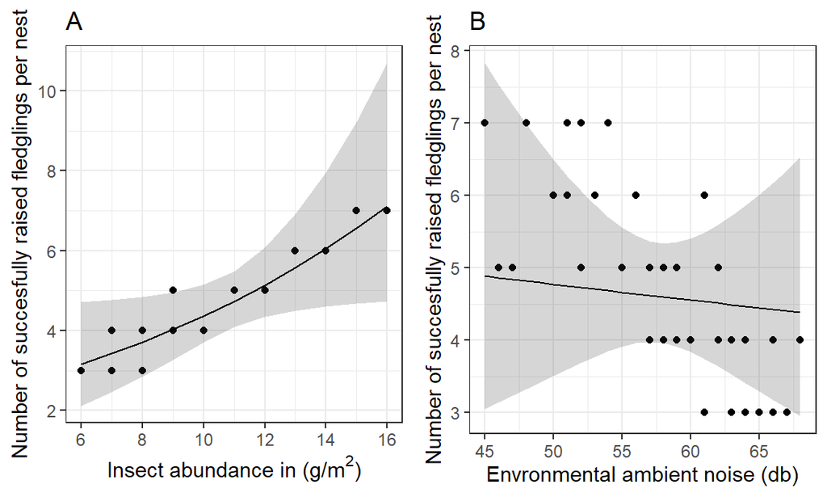

Figure 3: Raw data and model predictions to visualize the relationship between successfully raised fledglings per nest, A: Insect abundance close to the nest and B: the environmental ambient noise.

## 6 Store session information

```r
  version<- sessionInfo()
```